# Four-model ladder, bootstrap inference, and effect-size context

Deep immune cell phenotyping predicts influenza vaccine immunogenicity in HCT recipients

July 21, 2026

# 1 What this notebook does

This is the core quantitative notebook. It reports how much a patient’s pre-vaccination cellular composition improves prediction of the influenza antibody response, beyond the pre-vaccination titer and standard clinical factors, and it establishes that the improvement is statistically significant under inference that respects the correlated structure of the data.

It produces the manuscript’s three main tables and Figure 2, plus the supplementary noise-floor table:

- **Table 1** – prediction error (MSE) of the four-model ladder (M1–M4).
- **Table 2** – recipient-clustered bootstrap confidence intervals and p-values for each pairwise model comparison.
- **Figure 2** – the four-model ladder with those confidence intervals.
- **Table 3** – prediction error stratified by pre-vaccination titer quartile.
- **Supplementary Table (noise floor)** – model performance placed against the irreducible measurement noise of the HAI assay.

```r
# Edit these to your local copy of the intermediate data (not distributed; see
# README, Data Availability). With them present, this notebook knits by loading
# cached objects rather than re-running the nested cross-validation or bootstrap.
FAST <- "/fast/datasets/flu_cellular_prediction"
REPO <- "/home/amir/repo/flu-cellular-prediction"

AGG_PATH   <- file.path(FAST, "per_fold_atlas_5000", "aggregated", "E2_aggregated.RData")
PER_FOLD   <- file.path(FAST, "per_fold_atlas_5000")
BOOT_PATH  <- file.path(FAST, "post_hoc_5000", "recipient_bootstrap", "E3_recipient_boot.RData")
STRAT_PATH <- file.path(FAST, "post_hoc_5000", "stratified", "E2_stratified.RData")
NOISE_CSV  <- file.path(FAST, "post_hoc_5000", "E2_noise_floor.csv")

VIRUSES <- c("h1n1", "h3n2", "bvic")
antigen_label <- c(h1n1 = "H1N1", h3n2 = "H3N2", bvic = "B/Victoria")
```

# 2 The four models and how they are compared

The outcome is the log fold-rise in hemagglutination-inhibition (HAI) titer, $y = \log(\text{titer}_{\text{post}} / \text{titer}_{\text{pre}})$, measured for each of three influenza antigens (H1N1, H3N2, B/Victoria). We compare four nested models that differ only in which blocks of features they contain, so the change in error from one rung to the next isolates the contribution of the block that was added:

- **M1 (titers only)** – the three log pre-vaccination titers.
- **M2 (titers + clinical)** – M1 plus vaccine dose, age, sex, and time since transplant.
- **M3 (titers + clusters)** – M1 plus the cellular-composition features.
- **M4 (full)** – M2 plus the cellular-composition features.

All four are fit with the **same** regularized model family: a multitask elastic net (glmnet `mgaussian`, mixing parameter $\alpha = 0.9$) that predicts all three antigen responses jointly and shares one set of selected features across them. Using one model family throughout removes any confound between the amount of regularization and the addition of features. The cellular-composition features themselves are the centered-log-ratio (CLR) transform of each patient’s meta-cluster proportions,

$$\text{CLR}(\mathbf{p}_i)_j =
\log(p_{ij}) -
\tfrac{1}{k}\sum_{\ell=1}^{k}\log(p_{i\ell}),$$

which expresses each population’s abundance relative to the patient’s geometric-mean abundance (a pseudocount of 0.5 is added to raw counts to handle zero-count populations). Performance is measured by 5-fold nested cross-validation with folds grouped by recipient, and errors are aggregated across folds weighted by test-set size.

```r
if (file.exists(AGG_PATH)) {
  # Load the aggregated out-of-fold (held-out) predictions and outcomes.
  load(AGG_PATH)
} else {
  # ---- Self-contained aggregation of the five per-fold artifacts. This does
  #      not touch raw data; it stitches together the held-out predictions that
  #      the per-fold pipeline (notebook 01) already computed. ----
  fold_files <- file.path(PER_FOLD, sprintf("fold_%d", 1:5),
                          sprintf("fold_%d_all.RData", 1:5))
  if (!all(file.exists(fold_files)))
    stop("Neither the aggregated result nor the per-fold artifacts were found.")
  common_p_ids <- NULL
  acc <- list()
  for (f in fold_files) {
    e <- new.env(parent = emptyenv()); load(f, envir = e)
    acc[[length(acc) + 1]] <- list(ids = e$test_p_ids, Y = e$Y_test,
      M1 = e$pred_M1_en_test, M2 = e$pred_M2_en_test,
      M3 = e$pred_M3_en_test, M4 = e$pred_M4_en_test)
  }
  common_p_ids <- unlist(lapply(acc, function(a) a$ids))
  bind <- function(key) do.call(rbind, lapply(acc, function(a) a[[key]]))
  oof_Y         <- bind("Y")
  oof_pred_M1_en <- bind("M1"); oof_pred_M2_en <- bind("M2")
  oof_pred_M3_en <- bind("M3"); oof_pred_M4_en <- bind("M4")
}

# Held-out predictions for the four elastic-net models, aligned to oof_Y.
model_preds <- list(M1 = oof_pred_M1_en, M2 = oof_pred_M2_en,
                    M3 = oof_pred_M3_en, M4 = oof_pred_M4_en)
```

# 3 Table 1: four-model ladder prediction performance

Because every episode is predicted exactly once, while held out, the overall test-set-weighted MSE is simply the mean squared error across all episodes and antigens. Adding cellular-composition features to the titers-only baseline (M1 to M3) is the cleanest test of the cellular signal; adding them on top of the full clinical model (M2 to M4) is the most clinically relevant test.

```r
mse_of <- function(pred, v = NULL) {
  if (is.null(v)) mean((as.vector(pred) - as.vector(oof_Y))^2)
  else mean((pred[, v] - oof_Y[, v])^2)
}
table1 <- data.frame(
  Model    = names(model_preds),
  Features = c("Titers only", "Titers + clinical",
               "Titers + clusters", "Full (clinical + clusters)"),
  Overall  = sapply(model_preds, mse_of),
  H1N1     = sapply(model_preds, mse_of, v = "h1n1"),
  H3N2     = sapply(model_preds, mse_of, v = "h3n2"),
  `B/Victoria` = sapply(model_preds, mse_of, v = "bvic"),
  check.names = FALSE, row.names = NULL)

kable(table1, digits = 3, caption =
  "Table 1. Four-model ladder: n_test-weighted MSE from 5-fold nested cross-validation.")
```

Table 1. Four-model ladder: n_test-weighted MSE from 5-fold nested cross-validation.

| Model | Features | Overall | H1N1 | H3N2 | B/Victoria |
| --- | --- | --- | --- | --- | --- |
| M1 | Titers only | 3.418 | 3.389 | 3.734 | 3.129 |
| M2 | Titers + clinical | 3.340 | 3.328 | 3.599 | 3.093 |
| M3 | Titers + clusters | 3.121 | 3.171 | 3.368 | 2.822 |
| M4 | Full (clinical + clusters) | 3.117 | 3.156 | 3.347 | 2.848 |

Adding cluster features to baseline titers lowers overall MSE from 3.418 (M1) to 3.121 (M3). Clinical covariates alone (M1 to M2) move it only slightly, and once clusters are present the clinical covariates add essentially nothing (M3 to M4), indicating that cellular composition subsumes the predictive information in the standard clinical variables. The formal inference for each of these comparisons is in Table 2.

# 4 Table 2: recipient-clustered bootstrap inference

The 343 episodes are not independent: 80 recipients contributed two episodes, and every episode contributes three antigen measurements. Measurements from the same recipient resemble one another, so resampling individual rows would understate the true uncertainty. We therefore use a **recipient-clustered paired bootstrap**: we resample whole recipients with replacement ($B = 2{,}000$), and when a recipient is drawn, all of their episodes and all three antigen outcomes travel together as a block. For each replicate we recompute the percent MSE improvement; the 95% CI is the 2.5th–97.5th percentile and the p-value is two-sided. This bootstraps the smooth functional of paired prediction error (not the selected coefficients, whose bootstrap is known to be inconsistent).

```r
if (file.exists(BOOT_PATH)) {
  # Load the precomputed recipient-clustered bootstrap (fast).
  load(BOOT_PATH)   # provides results_df (data.table)
  boot_tab <- as.data.frame(results_df)
} else {
  # ---- Self-contained recipient-clustered bootstrap from the per-fold held-out
  #      predictions. No raw data needed; runs in seconds. ----
  fold_files <- file.path(PER_FOLD, sprintf("fold_%d", 1:5),
                          sprintf("fold_%d_all.RData", 1:5))
  if (!all(file.exists(fold_files)))
    stop("Recipient bootstrap needs either its cache or the per-fold artifacts.")
  dt <- rbindlist(lapply(fold_files, function(f) {
    e <- new.env(parent = emptyenv()); load(f, envir = e)
    rbindlist(lapply(seq_along(VIRUSES), function(vi) data.table(
      patient_id = e$test_p_ids, virus = VIRUSES[vi], Y_true = e$Y_test[, vi],
      pred_M1 = e$pred_M1_en_test[, vi], pred_M2 = e$pred_M2_en_test[, vi],
      pred_M3 = e$pred_M3_en_test[, vi], pred_M4 = e$pred_M4_en_test[, vi])))
  }))
  dt[, base_recipient := sub("_yr[0-9]+$", "", patient_id)]
  for (k in 1:4) set(dt, j = paste0("err_M", k),
                     value = (dt[[paste0("pred_M", k)]] - dt$Y_true)^2)
  rec_ids <- unique(dt$base_recipient)
  rec_rows <- split(seq_len(nrow(dt)), dt$base_recipient)[rec_ids]
  cmp <- data.frame(comparison = c("M1_to_M2","M1_to_M3","M1_to_M4",
                                   "M2_to_M3","M2_to_M4","M3_to_M4"),
                    a = c("M1","M1","M1","M2","M2","M3"),
                    b = c("M2","M3","M4","M3","M4","M4"),
                    stringsAsFactors = FALSE)
  boot_one <- function(a, b, i, B = 2000L) {
    ea <- dt[[paste0("err_", a)]]; eb <- dt[[paste0("err_", b)]]
    obs <- (mean(ea) - mean(eb)) / mean(ea) * 100
    set.seed(7000L + i)
    d <- vapply(seq_len(B), function(bi) {
      rows <- unlist(rec_rows[sample.int(length(rec_ids), length(rec_ids), TRUE)])
      (mean(ea[rows]) - mean(eb[rows])) / mean(ea[rows]) * 100
    }, numeric(1))
    p <- min(1, 2 * min(mean(d <= 0), mean(d >= 0)))
    data.frame(delta_pct = obs, ci_low_pct = quantile(d, .025),
               ci_high_pct = quantile(d, .975), p_two_sided = p)
  }
  boot_tab <- do.call(rbind, lapply(seq_len(nrow(cmp)), function(i)
    cbind(comparison = cmp$comparison[i], scope = "overall",
          boot_one(cmp$a[i], cmp$b[i], i))))
}

# Assemble Table 2 in the manuscript's row order (overall scope only).
row_order <- c("M1_to_M3", "M1_to_M4", "M2_to_M4", "M2_to_M3", "M1_to_M2", "M3_to_M4")
pretty_cmp <- c(
  M1_to_M3 = "M1->M3 (clusters over titers)",
  M1_to_M4 = "M1->M4 (full over titers)",
  M2_to_M4 = "M2->M4 (clusters over clinical)",
  M2_to_M3 = "M2->M3 (clusters vs clinical)",
  M1_to_M2 = "M1->M2 (clinical over titers)",
  M3_to_M4 = "M3->M4 (clinical on top of clusters)")
ov <- boot_tab[boot_tab$scope == "overall", ]
ov <- ov[match(row_order, ov$comparison), ]
table2 <- data.frame(
  Comparison = pretty_cmp[ov$comparison],
  `Delta MSE (%)` = round(ov$delta_pct, 1),
  `95% CI` = sprintf("[%.1f, %.1f]", ov$ci_low_pct, ov$ci_high_pct),
  `p (two-sided)` = sprintf("%.3f", ov$p_two_sided),
  check.names = FALSE, row.names = NULL)
kable(table2, caption =
  "Table 2. Recipient-clustered paired bootstrap (B = 2,000) for pairwise model comparisons.")
```

Table 2. Recipient-clustered paired bootstrap (B = 2,000) for pairwise model comparisons.

| Comparison | Delta MSE (%) | 95% CI | p (two-sided) |
| --- | --- | --- | --- |
| M1->M3 (clusters over titers) | 8.7 | [2.6, 15.0] | 0.006 |
| M1->M4 (full over titers) | 8.8 | [1.5, 16.0] | 0.017 |
| M2->M4 (clusters over clinical) | 6.7 | [0.8, 13.1] | 0.031 |
| M2->M3 (clusters vs clinical) | 6.6 | [0.3, 13.2] | 0.037 |
| M1->M2 (clinical over titers) | 2.3 | [-2.0, 6.9] | 0.289 |
| M3->M4 (clinical on top of clusters) | 0.1 | [-2.7, 3.0] | 0.932 |

The cluster signal is significant on the cleanest test controlling only for baseline titer (M1 to M3), on the most clinically relevant test beyond the full clinical model (M2 to M4), and head-to-head against all clinical covariates (M2 to M3). Clinical covariates alone (M1 to M2) are not significant, and add nothing once clusters are present (M3 to M4).

# 5 Figure 2: the four-model ladder with bootstrap confidence intervals

Figure 2 pairs the absolute MSE of the four models (left) with the percent improvement over M1 and its recipient-clustered 95% CI (right). The confidence intervals are the same recipient-clustered bootstrap intervals reported in Table 2, so the figure and table tell one consistent story.

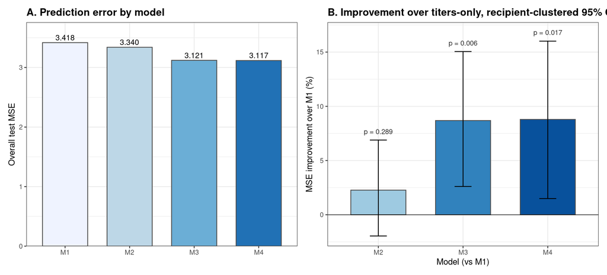

```r
# Left panel: absolute overall MSE for each model.
mse_df <- data.frame(model = names(model_preds),
                     mse = sapply(model_preds, mse_of))
mse_df$model <- factor(mse_df$model, levels = c("M1", "M2", "M3", "M4"))

p_left <- ggplot(mse_df, aes(model, mse, fill = model)) +
  geom_col(width = 0.7, color = "grey30", show.legend = FALSE) +
  geom_text(aes(label = sprintf("%.3f", mse)), vjust = -0.4, size = 3.5) +
  scale_fill_brewer(palette = "Blues") +
  scale_y_continuous(expand = expansion(mult = c(0, 0.1))) +
  labs(x = NULL, y = "Overall test MSE", title = "A. Prediction error by model") +
  theme_bw(base_size = 11) +
  theme(plot.title = element_text(face = "bold"))

# Right panel: improvement over M1 with recipient-clustered 95% CI + p-values.
imp <- ov[ov$comparison %in% c("M1_to_M2", "M1_to_M3", "M1_to_M4"), ]
imp$model <- c(M1_to_M2 = "M2", M1_to_M3 = "M3", M1_to_M4 = "M4")[imp$comparison]
imp$model <- factor(imp$model, levels = c("M2", "M3", "M4"))

p_right <- ggplot(imp, aes(model, delta_pct, fill = model)) +
  geom_col(width = 0.65, color = "grey30", show.legend = FALSE) +
  geom_errorbar(aes(ymin = ci_low_pct, ymax = ci_high_pct), width = 0.2) +
  geom_hline(yintercept = 0, linewidth = 0.3) +
  geom_text(aes(label = sprintf("p = %.3f", p_two_sided), y = ci_high_pct + 0.8),
            size = 3.2, color = "grey20") +
  scale_fill_manual(values = c(M2 = "#9ecae1", M3 = "#3182bd", M4 = "#08519c")) +
  labs(x = "Model (vs M1)", y = "MSE improvement over M1 (%)",
       title = "B. Improvement over titers-only, recipient-clustered 95% CI") +
  theme_bw(base_size = 11) +
  theme(plot.title = element_text(face = "bold"))

p_left | p_right
```

# 6 Table 3: stratified analysis by baseline titer quartile

Cellular profiling is expected to help most in patients whose pre-vaccination titers are low, because a high pre-vaccination titer both leaves little room for a fold-rise and already reflects humoral protection. To test this we split episodes into quartiles of the geometric-mean pre-vaccination titer across the three antigens, and recompute the M1 and M3 held-out MSE within each quartile.

```r
if (file.exists(STRAT_PATH)) {
  # Load the precomputed stratification (quartile labels + per-quartile MSE).
  load(STRAT_PATH)  # avg_baseline, quartile, stratified_mse, stratified_improvement
} else {
  # The quartile boundaries are derived from the mean pre-vaccination log-titer
  # (avg_baseline), which is a function of the withheld outcome table. The
  # per-quartile MSE is then computed from the held-out predictions above.
  stop("Stratified analysis needs its cache (avg_baseline / quartile labels).")
}

qlev <- c("Q1_low", "Q2", "Q3", "Q4_high")
# Titer ranges: exponentiate the log-titer quartile boundaries to recover the
# geometric-mean HAI dilution scale reported in the manuscript.
brks <- quantile(exp(avg_baseline), probs = c(0, .25, .5, .75, 1), na.rm = TRUE)
mse_q <- function(pred, idx) mean((as.vector(pred[idx, ]) - as.vector(oof_Y[idx, ]))^2)
table3 <- do.call(rbind, lapply(seq_along(qlev), function(i) {
  idx <- which(quartile == qlev[i])
  m1 <- mse_q(oof_pred_M1_en, idx); m3 <- mse_q(oof_pred_M3_en, idx)
  data.frame(
    Quartile = c("Q1 (low baseline)", "Q2", "Q3", "Q4 (high baseline)")[i],
    `Titer range` = sprintf("%.0f-%.0f", brks[i], brks[i + 1]),
    n = length(idx),
    `M1 MSE` = round(m1, 3), `M3 MSE` = round(m3, 3),
    `Improvement (%)` = round(100 * (m1 - m3) / m1, 1),
    check.names = FALSE, row.names = NULL)
}))
kable(table3, caption =
  "Table 3. Stratified prediction performance by baseline titer quartile (averaged across antigens).")
```

Table 3. Stratified prediction performance by baseline titer quartile (averaged across antigens).

| Quartile | Titer range | n | M1 MSE | M3 MSE | Improvement (%) |
| --- | --- | --- | --- | --- | --- |
| Q1 (low baseline) | 1-16 | 87 | 4.966 | 4.494 | 9.5 |
| Q2 | 16-50 | 86 | 3.898 | 3.375 | 13.4 |
| Q3 | 50-143 | 84 | 2.785 | 2.586 | 7.1 |
| Q4 (high baseline) | 143-6451 | 86 | 1.988 | 1.998 | -0.5 |

The gain from cellular composition is concentrated in the two lowest-titer quartiles – precisely the patients at greatest clinical risk of a weak response – and vanishes in the highest-titer quartile, consistent with the expected ceiling effect.

# 7 Supplementary table: measurement noise floor

HAI titers are read in doubling dilutions with roughly one-dilution-step precision, so a fixed share of the outcome variance is irreducible measurement noise. Treating one dilution step ($\log 2$ log-units) as one standard deviation gives $\sigma^2_\epsilon = (\log 2)^2 \approx 0.48$ and a theoretical $R^2$ ceiling near 0.90. This table places the four models against that floor: the headline 8.7% MSE improvement corresponds to closing about 10% of the improvable gap between the titers-only baseline and the noise floor.

```r
if (file.exists(NOISE_CSV)) {
  noise_floor <- read.csv(NOISE_CSV)
} else {
  # Self-contained: everything here is a function of the held-out predictions.
  sigma2 <- log(2)^2
  vY <- var(as.vector(oof_Y))
  mk <- function(pred) 1 - mse_of(pred) / vY
  noise_floor <- data.frame(virus = "overall", var_Y = vY, sigma2_noise = sigma2,
    R2_ceiling = 1 - sigma2 / vY,
    mean_mse_M1 = mse_of(oof_pred_M1_en), mean_mse_M4 = mse_of(oof_pred_M4_en),
    R2_M1 = mk(oof_pred_M1_en), R2_M4 = mk(oof_pred_M4_en))
}

nf <- noise_floor[noise_floor$virus == "overall", ]
sigma2 <- nf$sigma2_noise
noise_tab <- data.frame(
  Model = c("M1 (titers only)", "M2 (titers + clinical)",
            "M3 (titers + clusters)", "M4 (full)", "Perfect model (noise floor)"),
  MSE = c(mse_of(oof_pred_M1_en), mse_of(oof_pred_M2_en),
          mse_of(oof_pred_M3_en), mse_of(oof_pred_M4_en), sigma2),
  stringsAsFactors = FALSE)
noise_tab$RMSE <- sqrt(noise_tab$MSE)
noise_tab$`R2` <- 1 - noise_tab$MSE / nf$var_Y
noise_tab$`% of R2 ceiling` <- round(100 * noise_tab$`R2` / nf$R2_ceiling)
kable(noise_tab, digits = c(0, 3, 3, 2, 0), caption =
  "Supplementary Table. Model performance relative to the HAI noise floor.")
```

Supplementary Table. Model performance relative to the HAI noise floor.

| Model | MSE | RMSE | R2 | % of R2 ceiling |
| --- | --- | --- | --- | --- |
| M1 (titers only) | 3.418 | 1.849 | 0.28 | 31 |
| M2 (titers + clinical) | 3.340 | 1.828 | 0.30 | 33 |
| M3 (titers + clusters) | 3.121 | 1.767 | 0.34 | 38 |
| M4 (full) | 3.117 | 1.766 | 0.34 | 38 |
| Perfect model (noise floor) | 0.480 | 0.693 | 0.90 | 100 |

About 90% of the outcome variance is in principle explainable; the remaining ~10% is assay noise. The current models explain 28–34% of total variance, leaving room for larger cohorts or richer feature sets.